# Final_Project

Ahsan Sultan, Janvi Ahuja, Priyanshu Dey, Daniel Miller

2024-12-10

1. Part 1: Data Cleaning and Data Visualization – Complete without Generative AI
2. Part 2: Data Cleaning and Data Visualization – Complete with Generative AI
3. Part 3:Inference
4. Part 4: Prediction

```r
remove(list = ls())
#Loading in Essential Libraries
library(tidyverse)
```

```r
library(ggplot2)
library(e1071)
library(caTools)
library(caret)
library(randomForest)
#Loading in the Dataxdsw3
game_modes_df <- read.csv("CODGameModes.csv", stringsAsFactors = FALSE)
games_p1_df <- read.csv("CODGames_p1_380.csv", stringsAsFactors = FALSE)
games_p2_df <- read.csv("CODGames_p2_380.csv", stringsAsFactors = FALSE)
maps_df <- read.csv("CODMaps.csv", stringsAsFactors = FALSE)
```

# Task 1 - Data Cleaning and Data Visualization

After analyzing the structure of the two datasets, CODGames_p1_380 and CODGames_p2_380, we realized that these files contain similar data for individual players and their rankings in the game. Therefore, it made sense to merge the two dataframes into a single combined dataframe for a unified analysis.

Upon inspecting the data, we noticed that both datasets include null values in the Map1, Map2, and Choice columns. These null values must be handled carefully because rows with missing Choice values cannot determine a winner, so it was logical to remove them from the dataset. Additionally, there are trailing spaces in the map names, which can create inconsistencies when performing operations like counting or matching names. Cleaning these spaces was a necessary step for accuracy.

To ensure map names are clean and standardized, we used a reference list from the CODMaps.csv file. We implemented a function to compare and correct map names by matching them to valid names in the reference list. If a map name did not match any in the list, it was marked as NA to avoid inaccuracies in subsequent calculations.

For the winning criteria, we approached the problem in the following way:

We combined Map1 and Map2 into a single column to count the total appearances of each unique map as a candidate. We counted the number of times a map won by looking at the Choice column. To account for ties, where Map1 is selected as the default winner, the Choice values were treated appropriately during the win counting.

Finally, we calculated the win proportion for each map as the ratio of wins (WinCount) to total appearances (CandidateCount). The results were then sorted in descending order of win proportion to identify the maps with the best performance.

```r
# Combine datasets
combined <- bind_rows(games_p1_df, games_p2_df)

# Clean column names and map names
combined <- combined %>%
  rename_with(trimws) %>%
  mutate(
    Map1 = trimws(Map1),
    Map2 = trimws(Map2),
    Choice = trimws(Choice)
  )

maps_df <- maps_df %>%
  rename_with(trimws) %>%
  mutate(Name = trimws(Name))

valid_maps <- maps_df$Name

# Correct map names using a function
correct_map_name <- function(map_name, valid_names) {
  if (is.na(map_name)) return(map_name)
  for (valid_name in valid_names) {
    if (tolower(map_name) == tolower(valid_name)) {
      return(valid_name)
    }
  }
  return(NA)
}

# Apply the correction to Map1, Map2, and Choice
combined <- combined %>%
  mutate(
    Map1 = sapply(Map1, correct_map_name, valid_names = valid_maps),
    Map2 = sapply(Map2, correct_map_name, valid_names = valid_maps),
    Choice = sapply(Choice, correct_map_name, valid_names = valid_maps)
  )
```

```r
# Count total appearances as candidate (Map1 and Map2)
map_candidate_counts <- combined %>%
  pivot_longer(cols = c(Map1, Map2), names_to = "Position", values_to = "Map") %>%
  filter(!is.na(Map)) %>%
  count(Map, name = "CandidateCount")

# Count total wins
map_wins <- combined %>%
  filter(!is.na(Choice)) %>%
  count(Choice, name = "WinCount")

# Merge the counts and calculate win proportion
map_stats <- map_candidate_counts %>%
  full_join(map_wins, by = c("Map" = "Choice")) %>%
  mutate(
    WinCount = replace_na(WinCount, 0),
    WinProportion = WinCount / CandidateCount
  ) %>%
  arrange(desc(WinProportion))

# Display the table
print(map_stats)
```

```
## # A tibble: 28 × 4
##    Map               CandidateCount WinCount WinProportion
##    <chr>                      <int>    <int>         <dbl>
##  1 Standoff                      47       47         1
##  2 Crossroads Strike             58       54         0.931
##  3 Nuketown '84                  39       35         0.897
##  4 Raid                          43       37         0.860
##  5 Diesel                        55       47         0.855
##  6 Slums                         41       33         0.805
##  7 Collateral Strike             48       35         0.729
##  8 Rush                          45       32         0.711
##  9 Express                       62       44         0.710
## 10 Amerika                       27       19         0.704
## # ℹ 18 more rows
```

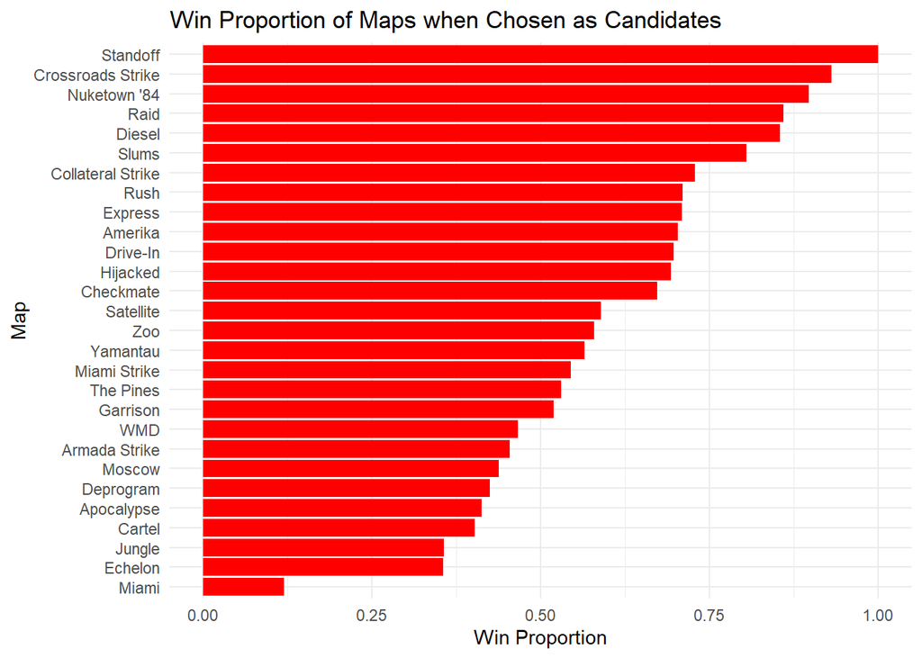

```r
# Bar chart for Win Proportion with Map on y-axis and Proportion on x-axis
ggplot(map_stats, aes(x = WinProportion, y = reorder(Map, WinProportion))) +
  geom_bar(stat = "identity", fill="red") +
  theme_minimal() +
  labs(
    title = "Win Proportion of Maps when Chosen as Candidates",
    x = "Win Proportion",
    y = "Map"
  )
```

# Task 2 - Data Cleaning and Data Visualization with Generative AI Tool Selection

Generative AI Tool Selection

For this task, we utilized ChatGPT (OpenAI GPT-4).

Prompts Used: We have a dataset containing information about video game voting, including two candidate maps (Map1 and Map2) and the final map selected (Choice). The dataset contains issues such as trailing spaces, null or missing values, and inconsistent map names. A reference list of valid map names is available in a separate file (CODMaps.csv). The first step is to clean the dataset by removing trailing spaces from map names, replacing invalid or unmatched map names with NA using the reference list, and eliminating rows where Choice is missing, as these rows do not contribute to win analysis.

After cleaning the dataset, the next step is to analyze the performance of each map. Specifically, we aim to count the total number of appearances for each map as a candidate by combining occurrences in Map1 and Map2. Additionally, we need to calculate the total number of wins for each map based on the Choice column while ensuring that missing values or invalid maps are excluded from the counts.

Using the candidate and win counts, we then calculate the win proportion for each map as the ratio of wins to total appearances, given by the formula:

The formula for win proportion is:

$$\text{Win Proportion} = \frac{\text{Win Count}}{\text{Candidate Count}}$$

To ensure completeness, any missing win counts or candidate counts should be replaced with zero. Finally, the results should be sorted in descending order of win proportion to identify the best-performing maps.

To visualize the results, we will create a horizontal bar chart using ggplot2. The x-axis will represent the win proportion, while the y-axis will list the maps, sorted in descending order of win proportion. The bars will be filled with a specific color, and a legend will be included to label the win proportion. This visualization will provide a clear and intuitive representation of each map’s performance based on the calculated win proportions.

```r
library(dplyr)
library(ggplot2)
library(tidyr)

# Load data
game_modes_df <- read.csv("CODGameModes.csv")
games_p1_df <- read.csv("CODGames_p1_380.csv")
games_p2_df <- read.csv("CODGames_p2_380.csv")
maps_df <- read.csv("CODMaps.csv")

# Combine datasets
games_df <- bind_rows(games_p1_df, games_p2_df)
```

```r
# Clean column names and map names
games_df <- games_df %>%
  rename_with(trimws) %>%
  mutate(
    Map1 = trimws(Map1),
    Map2 = trimws(Map2),
    Choice = trimws(Choice)
  )

maps_df <- maps_df %>%
  rename_with(trimws) %>%
  mutate(Name = trimws(Name))

valid_maps <- maps_df$Name

# Function to correct map names
correct_map_name <- function(map_name, valid_names) {
  if (is.na(map_name)) return(map_name)
  for (valid_name in valid_names) {
    if (tolower(map_name) == tolower(valid_name)) {
      return(valid_name)
    }
  }
  return(NA)  # Replace invalid names with NA
}

# Correct map names
games_df <- games_df %>%
  mutate(
    Map1 = sapply(Map1, correct_map_name, valid_names = valid_maps),
    Map2 = sapply(Map2, correct_map_name, valid_names = valid_maps),
    Choice = sapply(Choice, correct_map_name, valid_names = valid_maps)
  )
```

```r
# Count total occurrences of each map as a candidate
map_candidate_counts <- games_df %>%
  pivot_longer(cols = c(Map1, Map2), names_to = "Position", values_to = "Map") %>%
  filter(!is.na(Map)) %>%
  count(Map, name = "CandidateCount")

# Count total wins for each map
map_wins <- games_df %>%
  filter(!is.na(Choice)) %>%
  count(Choice, name = "WinCount")
```

```r
# Merge counts and calculate win probabilities
map_stats <- map_candidate_counts %>%
  full_join(map_wins, by = c("Map" = "Choice")) %>%
  mutate(
    WinCount = replace_na(WinCount, 0),
    CandidateCount = replace_na(CandidateCount, 0),
    WinProbability = ifelse(CandidateCount > 0, WinCount / CandidateCount, 0)
  ) %>%
  arrange(desc(WinProbability))

# Debugging: Print counts to verify no missing values or misaggregations
print("Map Candidate Counts:")
```

```
## [1] "Map Candidate Counts:"
```

```r
print(map_candidate_counts)
```

```
## # A tibble: 28 × 2
##    Map               CandidateCount
##    <chr>                      <int>
##  1 Amerika                       27
##  2 Apocalypse                    63
##  3 Armada Strike                 44
##  4 Cartel                        67
##  5 Checkmate                     55
##  6 Collateral Strike             48
##  7 Crossroads Strike             58
##  8 Deprogram                     40
##  9 Diesel                        55
## 10 Drive-In                      43
## # ℹ 18 more rows
```

```r
print("Map Wins:")
```

```
## [1] "Map Wins:"
```

```r
print(map_wins)
```

```
##               Choice WinCount
## 1            Amerika       19
## 2         Apocalypse       26
## 3      Armada Strike       20
## 4             Cartel       27
## 5          Checkmate       37
## 6  Collateral Strike       35
## 7  Crossroads Strike       54
## 8          Deprogram       17
## 9             Diesel       47
## 10          Drive-In       30
## 11           Echelon       16
## 12           Express       44
## 13          Garrison       27
## 14          Hijacked       34
## 15            Jungle        5
## 16             Miami        3
## 17      Miami Strike       30
## 18            Moscow       32
## 19      Nuketown '84       35
## 20              Raid       37
## 21              Rush       32
## 22         Satellite       23
## 23             Slums       33
## 24          Standoff       47
## 25         The Pines       35
## 26               WMD        7
## 27          Yamantau       39
## 28               Zoo       29
```

```r
print("Final Map Stats:")
```

```
## [1] "Final Map Stats:"
```

```r
print(map_stats)
```

```
## # A tibble: 28 × 4
##    Map               CandidateCount WinCount WinProbability
##    <chr>                      <int>    <int>          <dbl>
##  1 Standoff                      47       47          1
##  2 Crossroads Strike             58       54          0.931
##  3 Nuketown '84                  39       35          0.897
##  4 Raid                          43       37          0.860
##  5 Diesel                        55       47          0.855
##  6 Slums                         41       33          0.805
##  7 Collateral Strike             48       35          0.729
##  8 Rush                          45       32          0.711
##  9 Express                       62       44          0.710
## 10 Amerika                       27       19          0.704
## # ℹ 18 more rows
```

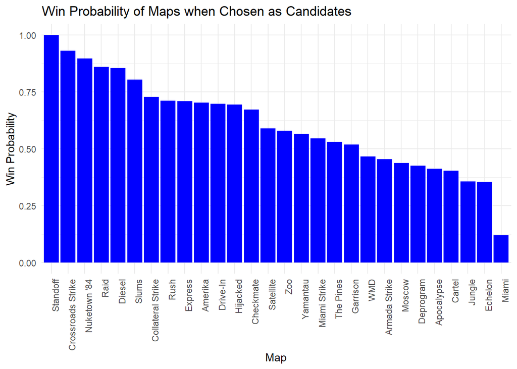

```r
# Visualization of Win Probabilities
ggplot(map_stats, aes(x = reorder(Map, -WinProbability), y = WinProbability)) +
  geom_bar(stat = "identity", fill = "blue") +
  theme_minimal() +
  theme(axis.text.x = element_text(angle = 90, hjust = 1)) +
  labs(
    title = "Win Probability of Maps when Chosen as Candidates",
    x = "Map",
    y = "Win Probability"
  )
```

Comparison: Generative AI vs. Manual Solution

The manual code takes a methodical, step-by-step approach. It systematically merges the datasets, removes inconsistencies, and carefully applies a function to validate and correct map names using a reference list (CODMaps.csv). The code is highly detailed, ensuring that all edge cases, such as unmatched or missing map names, are handled accurately. This thorough process makes the manual solution more robust and reliable, particularly when dealing with messy or incomplete datasets. However, the iterative logic in the manual approach can slow performance for larger datasets, and the step-by-step structure leads to longer code, which, while readable and easy to debug, may require more effort to implement.

# Task 3: Inference

## Relevant Information

**Research Question:** How does GameType affect TotalXP after accounting for the player’s Score?

## Data Cleaning

```r
# Clean GameType to merge HC and non-HC variants
combined <- combined %>%
  mutate(GameType = str_remove(GameType, "HC - ")) %>%
  mutate(GameType = str_trim(GameType))
```

## Summary Statistics

Explore the distribution of TotalXP across GameTypes.

```r
combined %>%
  group_by(GameType) %>%
  summarize(
    MeanXP = mean(TotalXP, na.rm = TRUE),
    MedianXP = median(TotalXP, na.rm = TRUE),
    Count = n()
  ) %>%
  arrange(desc(MeanXP))
```

```
## # A tibble: 4 × 4
##   GameType       MeanXP MedianXP Count
##   <chr>           <dbl>    <dbl> <int>
## 1 Domination     17997.   19358.    14
## 2 Hardpoint      17404.   15727    267
## 3 TDM            14633.   13815    537
## 4 Kill Confirmed 10782.    9630.    21
```

## Data Visualization

### Distribution of TotalXP by GameType

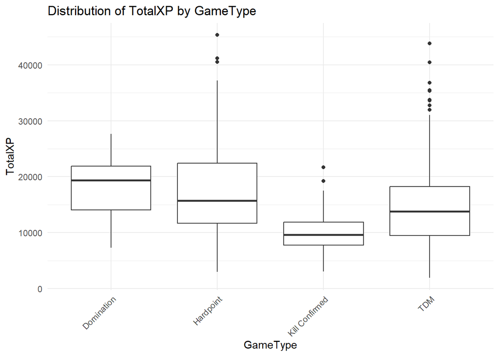

```r
ggplot(combined, aes(x = GameType, y = TotalXP)) +
  geom_boxplot() +
  theme_minimal() +
  labs(
    title = "Distribution of TotalXP by GameType",
    x = "GameType",
    y = "TotalXP"
  ) +
  theme(axis.text.x = element_text(angle = 45, hjust = 1))
```

### Scatter Plot of TotalXP vs. Score by GameType

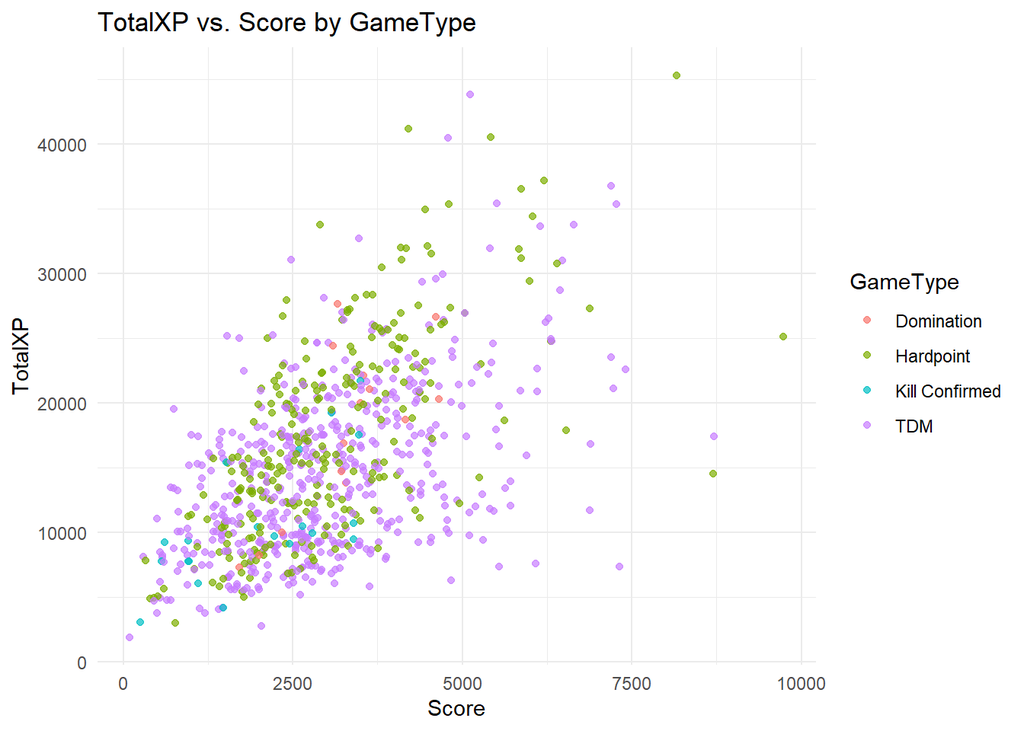

```r
ggplot(combined, aes(x = Score, y = TotalXP, color = GameType)) +
  geom_point(alpha = 0.7) +
  theme_minimal() +
  labs(
    title = "TotalXP vs. Score by GameType",
    x = "Score",
    y = "TotalXP",
    color = "GameType"
  )
```

## Modeling

### Base Model: TotalXP ~ Score + GameType

```r
base_model <- lm(TotalXP ~ Score + GameType, data = combined)
summary(base_model)
```

```
##
## Call:
## lm(formula = TotalXP ~ Score + GameType, data = combined)
##
## Residuals:
##      Min       1Q   Median       3Q      Max
## -18907.7  -4226.4   -332.6   3902.2  23463.2
##
## Coefficients:
##                          Estimate Std. Error t value Pr(>|t|)
## (Intercept)             9072.5914  1592.5597   5.697 1.71e-08 ***
## Score                      2.7052     0.1441  18.768  < 2e-16 ***
## GameTypeHardpoint        121.7613  1561.2263   0.078   0.9379
## GameTypeKill Confirmed -3703.1728  1990.5385  -1.860   0.0632 .
## GameTypeTDM            -2570.4367  1540.9337  -1.668   0.0957 .
## ---
## Signif. codes:  0 '***' 0.001 '**' 0.01 '*' 0.05 '.' 0.1 ' ' 1
##
## Residual standard error: 5687 on 803 degrees of freedom
##   (31 observations deleted due to missingness)
## Multiple R-squared:  0.3377, Adjusted R-squared:  0.3344
## F-statistic: 102.4 on 4 and 803 DF,  p-value: < 2.2e-16
```

### Improved Model: TotalXP ~ Score * GameType

```r
improved_model <- lm(TotalXP ~ Score * GameType, data = combined)
summary(improved_model)
```

```
##
## Call:
## lm(formula = TotalXP ~ Score * GameType, data = combined)
##
## Residuals:
##      Min       1Q   Median       3Q      Max
## -23620.1  -4130.1   -152.2   3626.4  24467.6
##
## Coefficients:
##                              Estimate Std. Error t value Pr(>|t|)
## (Intercept)                   141.168   6140.010   0.023  0.98166
## Score                           5.413      1.805   2.999  0.00279 **
## GameTypeHardpoint            6153.288   6198.660   0.993  0.32117
## GameTypeKill Confirmed       4637.698   6695.983   0.693  0.48876
## GameTypeTDM                  7788.913   6167.196   1.263  0.20697
## Score:GameTypeHardpoint        -1.752      1.823  -0.961  0.33680
## Score:GameTypeKill Confirmed   -2.412      2.155  -1.119  0.26344
## Score:GameTypeTDM              -3.182      1.813  -1.755  0.07961 .
## ---
## Signif. codes:  0 '***' 0.001 '**' 0.01 '*' 0.05 '.' 0.1 ' ' 1
##
## Residual standard error: 5615 on 800 degrees of freedom
##   (31 observations deleted due to missingness)
## Multiple R-squared:  0.3568, Adjusted R-squared:  0.3512
## F-statistic: 63.41 on 7 and 800 DF,  p-value: < 2.2e-16
```

```r
# Ensure residuals and fitted values match the dataset size
combined <- combined %>%
  filter(!is.na(TotalXP) & !is.na(Score)) %>%
  mutate(
    residuals = residuals(improved_model),
    fitted = fitted(improved_model)
  )
```

##### Explanation for the improved model:

The improved model incorporates an interaction term (Score * GameType) to explore whether the relationship between Score and TotalXP varies across different GameTypes. This is based on the idea that some GameTypes may reward specific in-game actions or objectives differently, and these rewards could scale with Score in distinct ways. By including the interaction term, we can investigate how the effect of Score on TotalXP changes depending on the GameType.

## Model Diagnostics: Residual Analysis

#### Residuals vs Fitted Values

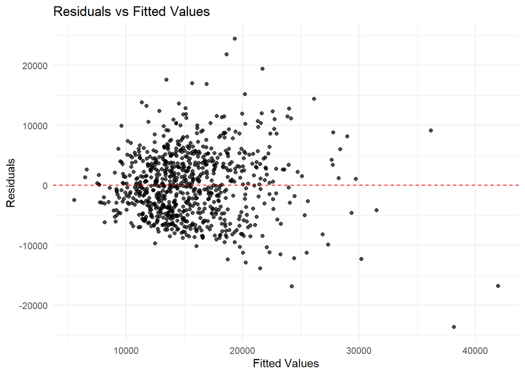

```r
ggplot(combined, aes(x = fitted, y = residuals)) +
  geom_point(alpha = 0.7) +
  geom_hline(yintercept = 0, color = "red", linetype = "dashed") +
  theme_minimal() +
  labs(
    title = "Residuals vs Fitted Values",
    x = "Fitted Values",
    y = "Residuals"
  )
```

#### QQ Plot for Residual Normality

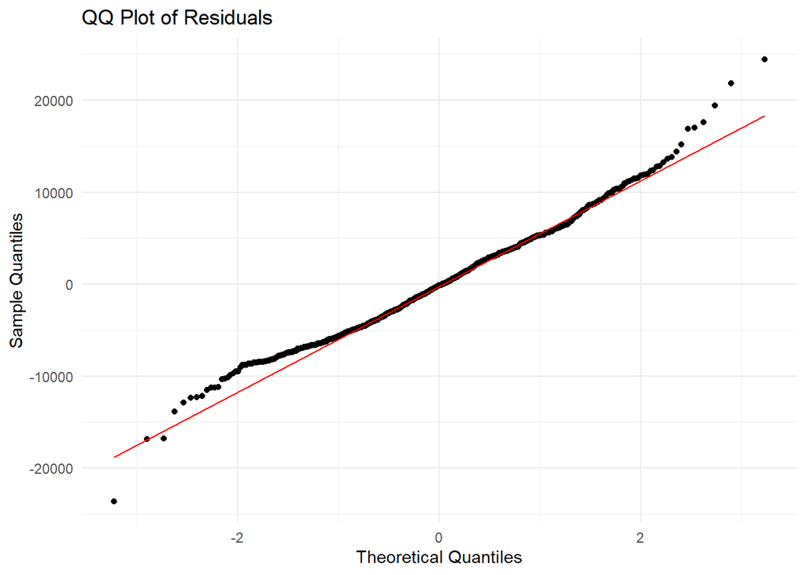

```r
ggplot(combined, aes(sample = residuals)) +
  geom_qq() +
  geom_qq_line(color = "red") +
  theme_minimal() +
  labs(
    title = "QQ Plot of Residuals",
    x = "Theoretical Quantiles",
    y = "Sample Quantiles"
  )
```

## Results and Interpretation

However, the models explain only about 35% of the variation in TotalXP, suggesting other factors, like player skill, time spent in-game, or specific in-game actions, also play a role. Including these variables could improve the model’s accuracy. Additionally, the Score-TotalXP relationship may not be strictly linear, and testing non-linear models could provide a better fit.

The interaction terms in the improved model highlight that the effect of Score on TotalXP varies by GameType, but most were not statistically significant. Simplifying the model by focusing only on significant interactions or using advanced methods like random forests may capture these relationships more effectively.

Residual analysis indicates the model assumptions are mostly met, but refining the models with transformations or regression techniques could address issues with the dataset.

# Task 4: Prediction

For this task, we will be performing a comparative analysis of three different predictive models. We have opted to include Random Forest, Logistic Regression, and Naive Bayes models. The Random Forest model was required to be used, we were able to refer to the Logistic Regression model used within the notes, and we referred to the Naive Bayes model included in the caret library (found [here](https://www.geeksforgeeks.org/naive-bayes-classifier-in-r-programming/)) to compare how the probabilistic model compares with the other respective models. However, before we are able to properly begin performing the model creation process, we will need to develop our research question.

### Research Question: How well can we predict the performance of the players team given the players individual metrics: Eliminations, Deaths, Score, and Damage?

Ultimately, we decided upon the variables: eliminations, Deaths, Score, and Damage for a couple of different reasons. Firstly, these are the statistical metrics of the players performance, and we have decided to include all except for the experience gain of the player as there are specific categories which create inconsistencies in the total experience gained in the match. Furthermore, if we decided to include only matches with a specific type of experience gain (XPType), then we will remove a significant amount of data from the model training which can impact the predictive capability of the different models. Therefore, we have decided to stick with the player performance metrics to predict the players team result. First, to implement the models we will need to perform some data cleaning to prepare the training data for the machine learning models.

### Data Cleaning

```r
split <- function(X) {
  # Handle missing values

  if (is.na(X) || X == "") {
    return(c(NA, NA))
  }

  # Split the string
  parts <- unlist(strsplit(X, "-"))

  # Convert to numeric and return
  return(as.numeric(parts))
}
```

```r
# Apply the function to all of the results and store the results in a new data frame
results <- sapply(X = combined$Result, FUN = split)
```

```r
# Store results as a data frame to create the Won variable
Results <- data.frame(
  Result = combined$Result,
  Player = results[1, ],
  Opposition = results[2, ]) %>%
  mutate(Won = ifelse(Player > Opposition, "Yes","No"))

combined$Won <- Results$Won

# Keep only the indices with no na's
combined <- combined[!is.na(combined$Won), ]

# Check the first 5 rows
combined %>%
  select(Result, Won) %>%
  head(5)
```

```
##   Result Won
## 1 100-97 Yes
## 2  76-89  No
## 3 100-92 Yes
## 4 80-100  No
## 5 71-100  No
```

```r
# Create indicator for Won
combined <-
  combined %>%
  mutate(Won_bit = ifelse(Won == "Yes", 1, 0))

# Check to make sure there are no na's
sum(is.na(combined$Won_bit))
```

```
## [1] 0
```

```r
# Create Train and Test split
set.seed(123)
trainInd <- sample(1:nrow(combined), floor(0.8 * nrow(combined)))
set.seed(NULL)

Train <- combined[trainInd, ]
Validation <- combined[-trainInd, ]
```

### Model Creation

```r
set.seed(123)

# Random forest model
rfModel <- randomForest(as.factor(Won) ~ Eliminations+Deaths+Score+Damage,
                        data = Train,
                        ntree = 500,
                        mtry = 3)

# Logistic regression model
logModel <- glm(Won_bit ~ Eliminations+Deaths+Score+Damage, family = binomial, data = Train)

# Naive Bayes Model
bayesModel <- naiveBayes(Won ~ Eliminations+Deaths+Score+Damage, data = Train)

set.seed(NULL)
```

### Model Exploration

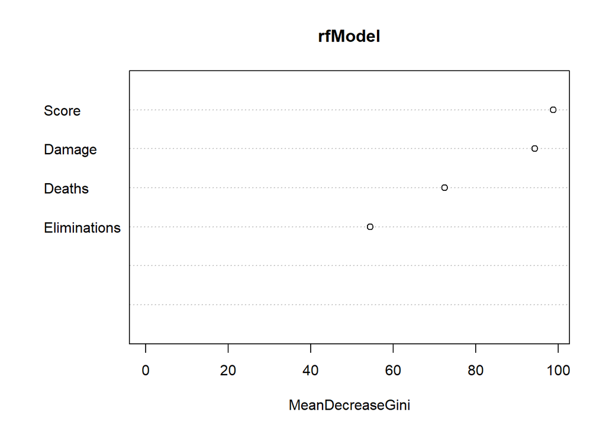

```r
# For Random Forest
varImpPlot(rfModel, n.var = 6)
```

```r
# For Logistic Regression
summary(logModel)
```

```
##
## Call:
## glm(formula = Won_bit ~ Eliminations + Deaths + Score + Damage,
##     family = binomial, data = Train)
##
## Coefficients:
##                Estimate Std. Error z value Pr(>|z|)
## (Intercept)   1.026e+00  3.024e-01   3.392 0.000694 ***
## Eliminations  1.127e-01  2.647e-02   4.257 2.08e-05 ***
## Deaths       -1.213e-01  1.695e-02  -7.156 8.33e-13 ***
## Score        -1.971e-04  1.141e-04  -1.727 0.084162 .
## Damage       -1.442e-04  8.771e-05  -1.644 0.100177
## ---
## Signif. codes:  0 '***' 0.001 '**' 0.01 '*' 0.05 '.' 0.1 ' ' 1
##
## (Dispersion parameter for binomial family taken to be 1)
##
##     Null deviance: 890.33  on 645  degrees of freedom
## Residual deviance: 815.85  on 641  degrees of freedom
## AIC: 825.85
##
## Number of Fisher Scoring iterations: 4
```

#### Naive Bayes model was summarized in the next section

### Model Evaluation

```r
# Generate results for Random Forest Model
predWon <- predict(rfModel, newdata = Validation)

#Create confusion matrix
table(predWon, Validation$Won)
```

```
##
## predWon No Yes
##     No  46  25
##     Yes 27  64
```

```r
#Calculate accuracy
mean(predWon == Validation$Won)
```

```
## [1] 0.6790123
```

```r
# Generate results for Logistic Regression Model

# Establish threshold
threshold <- 0.50

# Generate predictions
pred_prob <- predict(logModel, newdata = Validation, type = "response")

#
pred_won <- ifelse(pred_prob > threshold, "Yes", "No")

#Create confusion matrix
table(pred_won, Validation$Won)
```

```
##
## pred_won No Yes
##      No  43  16
##      Yes 30  73
```

```r
#Calculate accuracy
mean(pred_won == Validation$Won)
```

```
## [1] 0.7160494
```

```r
# Generate results for Naive Bayes Model
y_pred <- predict(bayesModel, newdata = Validation)
cm <- table(Validation$Won, y_pred)
confusionMatrix(cm)
```

```
## Confusion Matrix and Statistics
##
##      y_pred
##       No Yes
##   No  40  33
##   Yes 20  69
##
##                Accuracy : 0.6728
##                  95% CI : (0.5948, 0.7444)
##     No Information Rate : 0.6296
##     P-Value [Acc > NIR] : 0.14491
##
##                   Kappa : 0.3285
##
##  Mcnemar's Test P-Value : 0.09929
##
##             Sensitivity : 0.6667
##             Specificity : 0.6765
##          Pos Pred Value : 0.5479
##          Neg Pred Value : 0.7753
##              Prevalence : 0.3704
##          Detection Rate : 0.2469
##    Detection Prevalence : 0.4506
##       Balanced Accuracy : 0.6716
##
##        'Positive' Class : No
##
```

### Analysis of Models

Overall, the models performed with a very similar level of prediction accuracy with the Logistic Regression model with a threshold of 0.5 performing the best with an overall accuracy over 0.7. We decided to use a threshold for prediction probability of over 0.5 as the threshold so that we could divide the values in half, as we did not want the threshold to be a large determiner in the overall accuracy of the model predictions. The next highest performing model was the Random Forest model with an accuracy score of 0.679. Finally, the Naive Bayes model came in just behind with an overall accuracy of 0.672. It is pertinent to note that all of these scores were the result of the model predicting new data that we had originally separated when training the model.

While it is interesting to compare the different models, it is likely that for the purposes of predicting the team result relative to the players overall performance, roughly 70% accuracy from the different classification model applications is a fairly reasonable result. We can see this conceptually in the feature importance visual for the random forest and the summary of the logistic regression model. The models contain completely opposite feature importance hierarchy as determined by the decrease in gini gain and the coefficients respectively. As the random forest model obtains the largest gini gain from the Score and Damage variables, the Logistic Model uses the Eliminations and Deaths attributes to determine the team result. Overall, it is interesting to compare the different prediction metrics although our answer for our question ultimately lies around a predictive accuracy of 70% for the team result based on the individual player match performance attributes.